# PVT Pipeline Diagnostics

Analyse CSV logs from diagnostic clones of the inference and PVT streamer nodes. Compare runs at different velocity/acceleration settings to diagnose vibration.

**Testing strategy** (two phases):

1. **Phase 1** -- Sweep streamer speed (velocity_scale, accel_scale) while holding inference feedback constant
2. **Phase 2** -- Sweep inference feedback (feedback_gain, feedback_max_vel) while holding streamer at fastest stable setting from Phase 1

```python
import pandas as pd
import numpy as np
import matplotlib.pyplot as plt
from pathlib import Path

%matplotlib inline
plt.rcParams['figure.figsize'] = (16, 4)
plt.rcParams['figure.dpi'] = 100

DIAG_DIR = Path('/data/processed/diagnostics')
JOINT_NAMES = ['j0 (shoulder)', 'j1 (arm)', 'j2 (elbow)', 'j3 (wrist1)', 'j4 (wrist2)', 'j5 (wrist3)']

def get_run_params(df_inf, df_str):
    """Extract run parameters from CSV data (first row)."""
    params = {}
    for col in ['feedback_gain', 'feedback_max_vel', 'control_rate_hz',
                'max_joint_velocity_rad_s', 'max_joint_acceleration_rad_s2']:
        if col in df_inf.columns:
            params[col] = df_inf[col].iloc[0]
    for col in ['velocity_scale', 'accel_scale', 'filter_type', 'pvt_rate_hz']:
        if col in df_str.columns:
            params[col] = df_str[col].iloc[0]
    return params

def make_run_label(params):
    """Build a human-readable label from parameters."""
    parts = []
    if 'velocity_scale' in params:
        parts.append(f"vs={params['velocity_scale']}")
    if 'accel_scale' in params:
        parts.append(f"as={params['accel_scale']}")
    if 'feedback_gain' in params:
        parts.append(f"Kp={params['feedback_gain']}")
    if 'feedback_max_vel' in params:
        parts.append(f"mv={params['feedback_max_vel']}")
    return ', '.join(parts)
```

## 1. Load Data

Set the label for the run you want to analyse (or leave blank to pick latest).

```python
LABEL = ''  # e.g. 'baseline', 'str_med', 'fb_high'

def find_latest(prefix, label=''):
    pattern = f'{prefix}*{label}*.csv' if label else f'{prefix}*.csv'
    files = sorted(DIAG_DIR.glob(pattern), key=lambda p: p.stat().st_mtime)
    if not files:
        raise FileNotFoundError(f'No files matching {pattern} in {DIAG_DIR}')
    return files[-1]

inf_path = find_latest('inference_diag', LABEL)
str_path = find_latest('streamer_diag', LABEL)
print(f'Inference CSV: {inf_path.name}')
print(f'Streamer CSV:  {str_path.name}')

df_inf = pd.read_csv(inf_path)
df_str = pd.read_csv(str_path)

for df, name in [(df_inf, 'inference'), (df_str, 'streamer')]:
    df['t'] = df['timestamp'] - df['timestamp'].iloc[0]
    print(f'\n{name}: {len(df)} rows, {df["t"].iloc[-1]:.1f}s duration, '
          f'avg dt={df["dt_actual"].mean()*1000:.1f}ms')

# Show parameters used for this run
params = get_run_params(df_inf, df_str)
print(f'\nRun parameters:')
for k, v in params.items():
    print(f'  {k}: {v}')
```

```
Inference CSV: inference_diag_fast_rate_20260414_025657.csv
Streamer CSV:  streamer_diag_fast_rate_20260414_045653.csv

inference: 6102 rows, 30.6s duration, avg dt=5.0ms

streamer: 467 rows, 31.1s duration, avg dt=67.1ms

Run parameters:
  feedback_gain: 25.0
  feedback_max_vel: 50.0
  control_rate_hz: 200.0
  max_joint_velocity_rad_s: 20.0
  max_joint_acceleration_rad_s2: 50.0
  velocity_scale: 0.2
  accel_scale: 0.1
  filter_type: none
  pvt_rate_hz: 15.0
```

## 2. Inference Pipeline Traces

Per-joint view of every pipeline stage: raw model output -> safety clamp -> filter -> final target vs actual robot position.

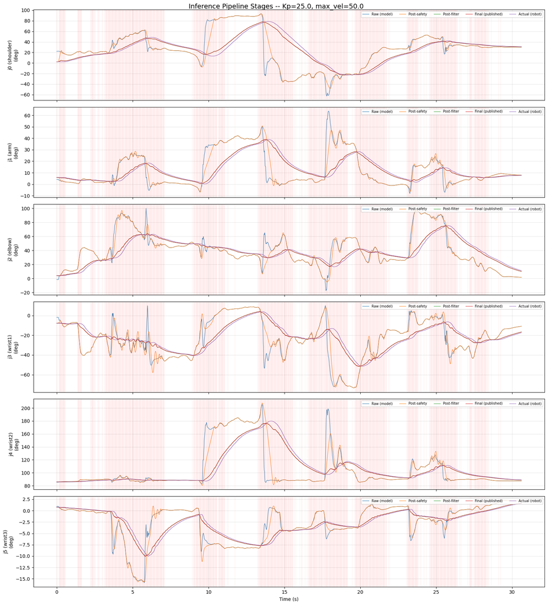

```python
fig, axes = plt.subplots(6, 1, figsize=(16, 18), sharex=True)
stages = [
    ('raw', 'tab:blue', 'Raw (model)'),
    ('safety', 'tab:orange', 'Post-safety'),
    ('filtered', 'tab:green', 'Post-filter'),
    ('final', 'tab:red', 'Final (published)'),
    ('actual', 'tab:purple', 'Actual (robot)'),
]
for i in range(6):
    ax = axes[i]
    for prefix, color, label in stages:
        col = f'{prefix}_j{i}'
        if col in df_inf.columns:
            ax.plot(df_inf['t'], np.degrees(df_inf[col]), color=color, label=label,
                    linewidth=0.8, alpha=0.9)
    if 'safety_was_constrained' in df_inf.columns:
        mask = df_inf['safety_was_constrained'] == 1
        if mask.any():
            for t_val in df_inf.loc[mask, 't'].values[::5]:
                ax.axvline(t_val, color='red', alpha=0.05, linewidth=1)
    ax.set_ylabel(f'{JOINT_NAMES[i]}\n(deg)')
    ax.legend(loc='upper right', fontsize=7, ncol=5)
    ax.grid(True, alpha=0.3)
axes[-1].set_xlabel('Time (s)')
title = f'Inference Pipeline Stages -- Kp={params.get("feedback_gain","?")}, max_vel={params.get("feedback_max_vel","?")}'
fig.suptitle(title, fontsize=14)
plt.tight_layout()
plt.show()
```

## 3. Streamer Pipeline Traces

Per-joint view through the PVT streamer: input target -> collision-safe -> filtered -> sent position vs actual robot.

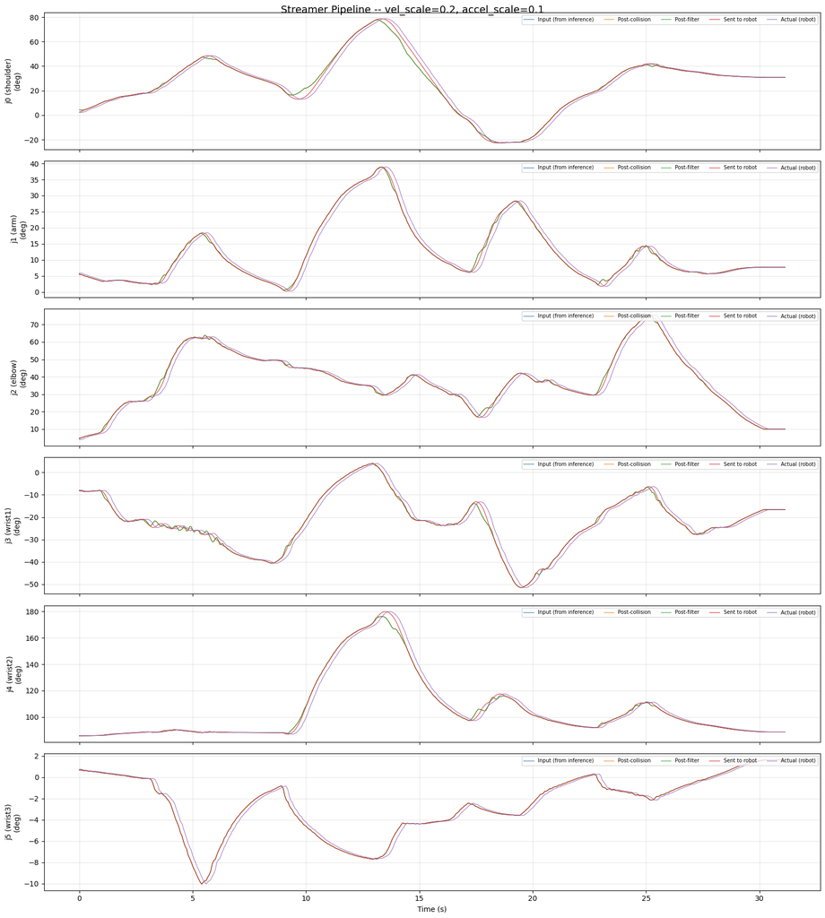

```python
fig, axes = plt.subplots(6, 1, figsize=(16, 18), sharex=True)
stages = [
    ('input', 'tab:blue', 'Input (from inference)'),
    ('safe', 'tab:orange', 'Post-collision'),
    ('filtered', 'tab:green', 'Post-filter'),
    ('sent_pos', 'tab:red', 'Sent to robot'),
    ('actual', 'tab:purple', 'Actual (robot)'),
]
for i in range(6):
    ax = axes[i]
    for prefix, color, label in stages:
        col = f'{prefix}_j{i}'
        if col in df_str.columns:
            ax.plot(df_str['t'], np.degrees(df_str[col]), color=color, label=label,
                    linewidth=0.8, alpha=0.9)
    ax.set_ylabel(f'{JOINT_NAMES[i]}\n(deg)')
    ax.legend(loc='upper right', fontsize=7, ncol=5)
    ax.grid(True, alpha=0.3)
axes[-1].set_xlabel('Time (s)')
title = f'Streamer Pipeline -- vel_scale={params.get("velocity_scale","?")}, accel_scale={params.get("accel_scale","?")}'
fig.suptitle(title, fontsize=14)
plt.tight_layout()
plt.show()
```

## 3b. Inference vs Streamer: What Goes In vs What Comes Out

Direct overlay per joint: inference published target (what the streamer receives) vs what the streamer actually sends to the robot vs actual robot position. The gap between these lines shows how much the streamer's velocity/accel clamping distorts the inference signal.

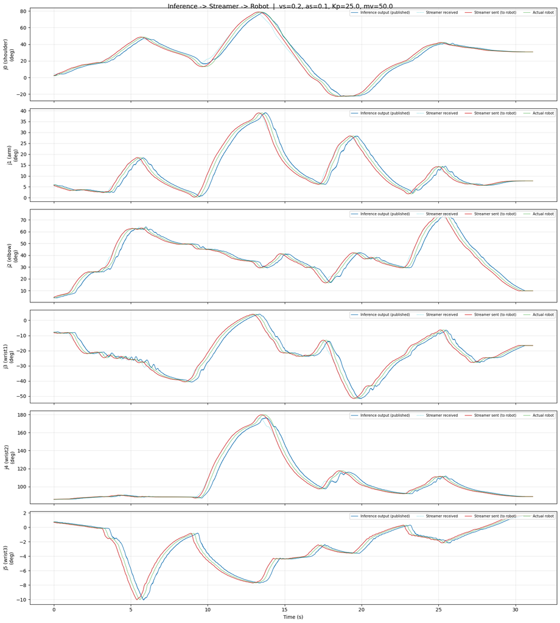

```python
fig, axes = plt.subplots(6, 1, figsize=(16, 18), sharex=True)
for i in range(6):
    ax = axes[i]
    # Inference final output (what gets published to /vam/joint_targets)
    if f'final_j{i}' in df_inf.columns:
        ax.plot(df_inf['t'], np.degrees(df_inf[f'final_j{i}']),
                color='tab:blue', linewidth=1.0, label='Inference output (published)')
    # Streamer input (what it received -- should match inference output)
    if f'input_j{i}' in df_str.columns:
        ax.plot(df_str['t'], np.degrees(df_str[f'input_j{i}']),
                color='tab:cyan', linewidth=0.6, linestyle='--', alpha=0.7,
                label='Streamer received')
    # Streamer sent (what actually goes to robot after vel/accel clamping)
    if f'sent_pos_j{i}' in df_str.columns:
        ax.plot(df_str['t'], np.degrees(df_str[f'sent_pos_j{i}']),
                color='tab:red', linewidth=1.0, label='Streamer sent (to robot)')
    # Actual robot position
    if f'actual_j{i}' in df_str.columns:
        ax.plot(df_str['t'], np.degrees(df_str[f'actual_j{i}']),
                color='tab:green', linewidth=0.8, alpha=0.7, label='Actual robot')
    ax.set_ylabel(f'{JOINT_NAMES[i]}\n(deg)')
    ax.legend(loc='upper right', fontsize=7, ncol=4)
    ax.grid(True, alpha=0.3)
axes[-1].set_xlabel('Time (s)')
title = (f'Inference -> Streamer -> Robot'
         f'  |  vs={params.get("velocity_scale","?")}, as={params.get("accel_scale","?")}'
         f', Kp={params.get("feedback_gain","?")}, mv={params.get("feedback_max_vel","?")}')
fig.suptitle(title, fontsize=13)
plt.tight_layout()
plt.show()
```

### Streamer distortion: how much does the streamer change the inference signal?

Per-joint RMS and max difference between what inference published and what the streamer sent.

```python
# Align inference and streamer by nearest timestamp
# (inference runs at higher rate, so downsample to streamer timestamps)
from scipy.interpolate import interp1d

print(f'Inference rate: {1.0/df_inf["dt_actual"].astype(float).median():.0f} Hz')
print(f'Streamer rate:  {1.0/df_str["dt_actual"].astype(float).median():.0f} Hz')
print()

# Interpolate inference output at streamer timestamps
inf_t = df_inf['timestamp'].values
str_t = df_str['timestamp'].values

print(f'{"Joint":<15} {"RMS diff (deg)":>15} {"Max diff (deg)":>15} {"Mean lag (ms)":>15}')
print('-' * 62)
for i in range(6):
    inf_col = f'final_j{i}'
    str_input_col = f'input_j{i}'
    str_sent_col = f'sent_pos_j{i}'
    if inf_col in df_inf.columns and str_sent_col in df_str.columns:
        # Interpolate inference at streamer times
        f_interp = interp1d(inf_t, df_inf[inf_col].values,
                           kind='nearest', fill_value='extrapolate')
        inf_at_str = f_interp(str_t)
        sent = df_str[str_sent_col].values
        diff = np.degrees(inf_at_str - sent)
        rms = np.sqrt(np.mean(diff**2))
        maxd = np.max(np.abs(diff))
        # Estimate lag: cross-correlation peak offset
        if len(inf_at_str) > 20:
            corr = np.correlate(inf_at_str - inf_at_str.mean(),
                                sent - sent.mean(), mode='full')
            dt_str = np.median(np.diff(str_t))
            lag_samples = corr.argmax() - (len(sent) - 1)
            lag_ms = lag_samples * dt_str * 1000
        else:
            lag_ms = 0
        print(f'{JOINT_NAMES[i]:<15} {rms:>15.2f} {maxd:>15.2f} {lag_ms:>15.1f}')
```

```
Inference rate: 200 Hz
Streamer rate:  15 Hz

Joint            RMS diff (deg)  Max diff (deg)   Mean lag (ms)
--------------------------------------------------------------
j0 (shoulder)              1.88            7.58             0.0
j1 (arm)                   0.42            2.67             0.0
j2 (elbow)                 0.69            4.17             0.0
j3 (wrist1)                0.71            4.33             0.0
j4 (wrist2)                1.33            9.37             0.0
j5 (wrist3)                0.03            0.15             0.0
```

## 4. Velocity Profiles

Desired vs clamped vs ramped velocity per joint. Horizontal lines show hardware velocity limits.

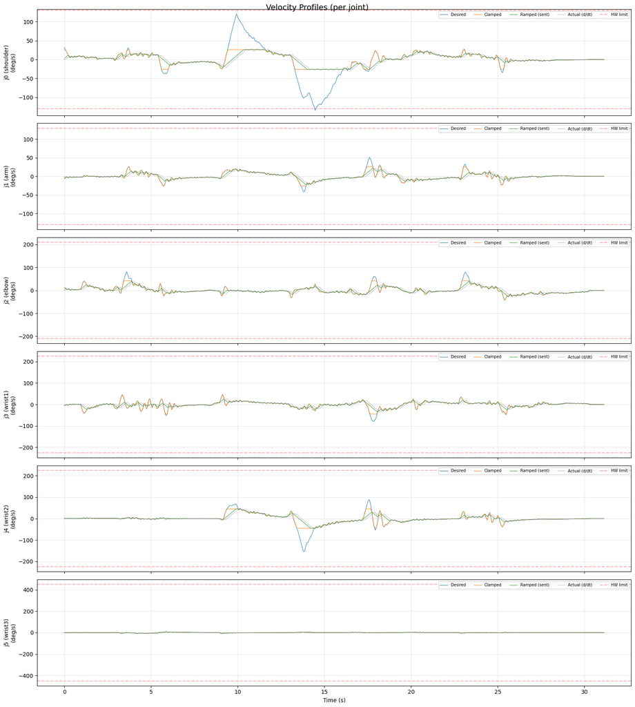

```python
TM12S_HW_VEL = np.array([2.27, 2.27, 3.67, 3.93, 3.93, 7.85])

fig, axes = plt.subplots(6, 1, figsize=(16, 18), sharex=True)
vel_stages = [
    ('desired_vel', 'tab:blue', 'Desired'),
    ('clamped_vel', 'tab:orange', 'Clamped'),
    ('ramped_vel', 'tab:green', 'Ramped (sent)'),
]
for i in range(6):
    ax = axes[i]
    for prefix, color, label in vel_stages:
        col = f'{prefix}_j{i}'
        if col in df_str.columns:
            ax.plot(df_str['t'], np.degrees(df_str[col]), color=color, label=label,
                    linewidth=0.8, alpha=0.9)
    if f'actual_j{i}' in df_str.columns and len(df_str) > 1:
        actual_vel = np.gradient(df_str[f'actual_j{i}'].values, df_str['t'].values)
        ax.plot(df_str['t'], np.degrees(actual_vel), color='tab:purple',
                label='Actual (d/dt)', linewidth=0.6, alpha=0.6)
    hw_deg = np.degrees(TM12S_HW_VEL[i])
    ax.axhline(hw_deg, color='red', linestyle='--', alpha=0.3, label=f'HW limit')
    ax.axhline(-hw_deg, color='red', linestyle='--', alpha=0.3)
    ax.set_ylabel(f'{JOINT_NAMES[i]}\n(deg/s)')
    ax.legend(loc='upper right', fontsize=7, ncol=5)
    ax.grid(True, alpha=0.3)
axes[-1].set_xlabel('Time (s)')
fig.suptitle('Velocity Profiles (per joint)', fontsize=14)
plt.tight_layout()
plt.show()
```

## 5. Acceleration Analysis

Numerical derivative of ramped velocity. Primary suspect for vibration when acceleration limiting kicks in hard.

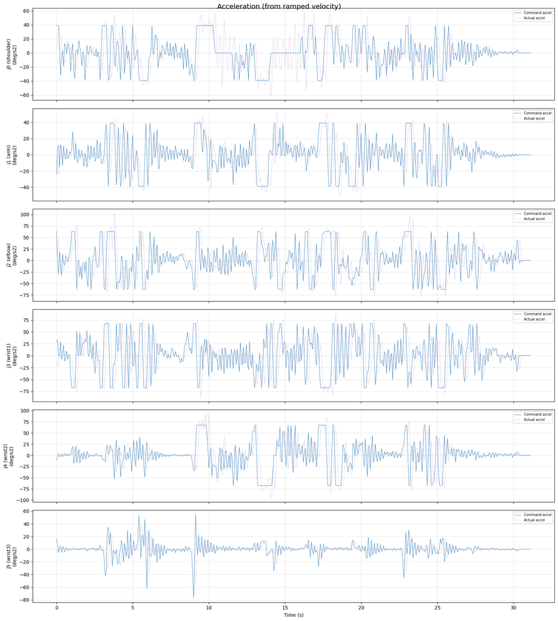

```python
fig, axes = plt.subplots(6, 1, figsize=(16, 18), sharex=True)
for i in range(6):
    ax = axes[i]
    col = f'ramped_vel_j{i}'
    if col in df_str.columns and len(df_str) > 1:
        vel = df_str[col].values
        t = df_str['t'].values
        accel = np.gradient(vel, t)
        ax.plot(t, np.degrees(accel), color='tab:blue', linewidth=0.6, label='Command accel')
    act_col = f'actual_j{i}'
    if act_col in df_str.columns and len(df_str) > 2:
        actual_vel = np.gradient(df_str[act_col].values, t)
        actual_accel = np.gradient(actual_vel, t)
        ax.plot(t, np.degrees(actual_accel), color='tab:purple', linewidth=0.4,
                alpha=0.5, label='Actual accel')
    ax.set_ylabel(f'{JOINT_NAMES[i]}\n(deg/s2)')
    ax.legend(loc='upper right', fontsize=7)
    ax.grid(True, alpha=0.3)
axes[-1].set_xlabel('Time (s)')
fig.suptitle('Acceleration (from ramped velocity)', fontsize=14)
plt.tight_layout()
plt.show()
```

## 6. Tracking Error

|target - actual| per joint over time. Oscillation = vibration.

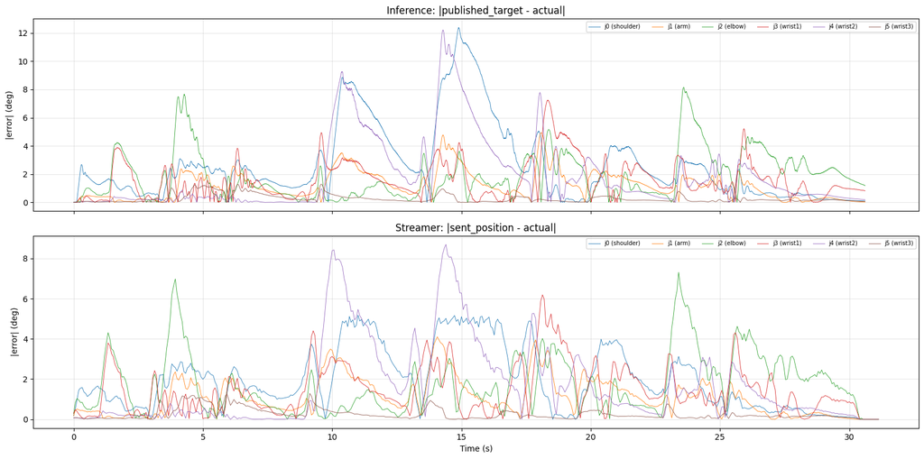

```python
fig, axes = plt.subplots(2, 1, figsize=(16, 8), sharex=True)

ax = axes[0]
for i in range(6):
    if f'final_j{i}' in df_inf.columns and f'actual_j{i}' in df_inf.columns:
        err = np.degrees(np.abs(df_inf[f'final_j{i}'] - df_inf[f'actual_j{i}']))
        ax.plot(df_inf['t'], err, linewidth=0.6, label=JOINT_NAMES[i])
ax.set_ylabel('|error| (deg)')
ax.set_title('Inference: |published_target - actual|')
ax.legend(loc='upper right', fontsize=7, ncol=6)
ax.grid(True, alpha=0.3)

ax = axes[1]
for i in range(6):
    if f'sent_pos_j{i}' in df_str.columns and f'actual_j{i}' in df_str.columns:
        err = np.degrees(np.abs(df_str[f'sent_pos_j{i}'] - df_str[f'actual_j{i}']))
        ax.plot(df_str['t'], err, linewidth=0.6, label=JOINT_NAMES[i])
ax.set_ylabel('|error| (deg)')
ax.set_title('Streamer: |sent_position - actual|')
ax.legend(loc='upper right', fontsize=7, ncol=6)
ax.grid(True, alpha=0.3)
axes[-1].set_xlabel('Time (s)')
plt.tight_layout()
plt.show()
```

## 7. FFT Frequency Analysis

FFT of tracking error (sent - actual) to identify vibration frequencies. Peaks at specific frequencies indicate resonance or control loop issues.

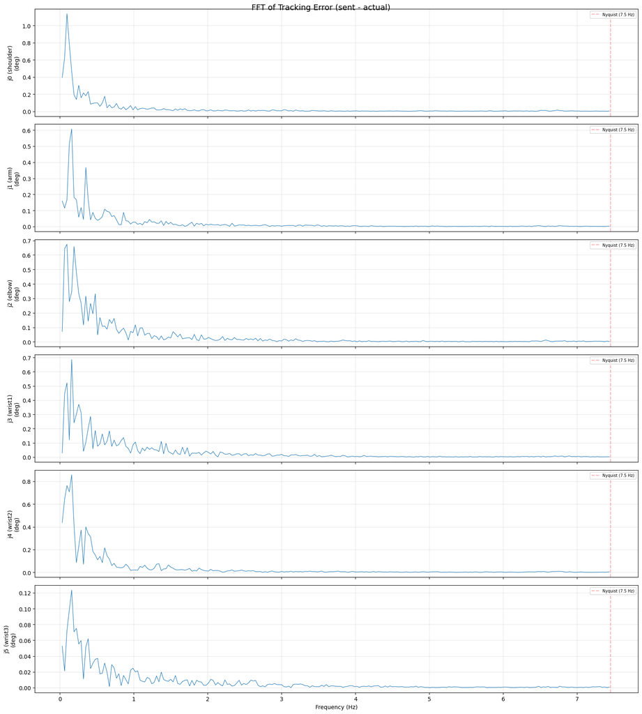

```python
fig, axes = plt.subplots(6, 1, figsize=(16, 18), sharex=True)
for i in range(6):
    ax = axes[i]
    if f'sent_pos_j{i}' in df_str.columns and f'actual_j{i}' in df_str.columns:
        err = (df_str[f'sent_pos_j{i}'] - df_str[f'actual_j{i}']).values
        dt_mean = df_str['dt_actual'].astype(float).mean()
        fs = 1.0 / dt_mean if dt_mean > 0 else 15.0
        n = len(err)
        if n > 10:
            err = err - np.mean(err)
            freqs = np.fft.rfftfreq(n, d=dt_mean)
            fft_mag = np.abs(np.fft.rfft(err)) / n
            ax.plot(freqs[1:], np.degrees(fft_mag[1:]), linewidth=0.8)
            ax.axvline(fs/2, color='red', linestyle='--', alpha=0.3,
                       label=f'Nyquist ({fs/2:.1f} Hz)')
            ax.legend(loc='upper right', fontsize=7)
    ax.set_ylabel(f'{JOINT_NAMES[i]}\n(deg)')
    ax.grid(True, alpha=0.3)
axes[-1].set_xlabel('Frequency (Hz)')
fig.suptitle('FFT of Tracking Error (sent - actual)', fontsize=14)
plt.tight_layout()
plt.show()
```

## 8. Timing Jitter

Histogram and time series of actual dt between ticks. Also PVT send_script call latency.

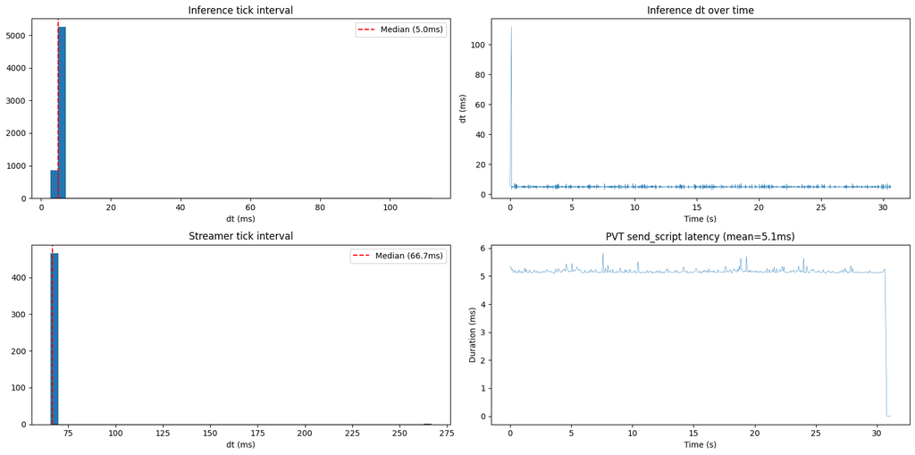

```python
fig, axes = plt.subplots(2, 2, figsize=(16, 8))

ax = axes[0, 0]
dt_ms = df_inf['dt_actual'].astype(float) * 1000
ax.hist(dt_ms, bins=50, edgecolor='black', linewidth=0.3)
ax.axvline(dt_ms.median(), color='red', linestyle='--', label=f'Median ({dt_ms.median():.1f}ms)')
ax.set_xlabel('dt (ms)')
ax.set_title('Inference tick interval')
ax.legend()

ax = axes[0, 1]
ax.plot(df_inf['t'], dt_ms, linewidth=0.4)
ax.set_xlabel('Time (s)')
ax.set_ylabel('dt (ms)')
ax.set_title('Inference dt over time')

ax = axes[1, 0]
dt_ms_str = df_str['dt_actual'].astype(float) * 1000
ax.hist(dt_ms_str, bins=50, edgecolor='black', linewidth=0.3)
ax.axvline(dt_ms_str.median(), color='red', linestyle='--', label=f'Median ({dt_ms_str.median():.1f}ms)')
ax.set_xlabel('dt (ms)')
ax.set_title('Streamer tick interval')
ax.legend()

ax = axes[1, 1]
if 'pvt_send_duration_ms' in df_str.columns:
    send_ms = df_str['pvt_send_duration_ms'].astype(float)
    ax.plot(df_str['t'], send_ms, linewidth=0.4)
    ax.set_xlabel('Time (s)')
    ax.set_ylabel('Duration (ms)')
    ax.set_title(f'PVT send_script latency (mean={send_ms.mean():.1f}ms)')
plt.tight_layout()
plt.show()
```

## 9. Multi-Run Comparison -- Load All Runs

Automatically discovers all CSV pairs, reads parameters from the data itself.

```python
def load_all_runs():
    """Load all inference+streamer CSV pairs and extract parameters."""
    inf_files = sorted(DIAG_DIR.glob('inference_diag_*.csv'), key=lambda p: p.stat().st_mtime)
    str_files = sorted(DIAG_DIR.glob('streamer_diag_*.csv'), key=lambda p: p.stat().st_mtime)
    print(f'Found {len(inf_files)} inference + {len(str_files)} streamer CSVs')

    runs = []
    # Pair by matching diag_label in filename (between prefix and timestamp)
    # e.g. inference_diag_baseline_20260414_153000.csv -> label = "baseline"
    def extract_label(path, prefix):
        stem = path.stem  # e.g. inference_diag_baseline_20260414_153000
        rest = stem[len(prefix):]  # e.g. _baseline_20260414_153000
        if rest.startswith('_'):
            rest = rest[1:]
        # Last two parts are date_time
        parts = rest.rsplit('_', 2)
        return parts[0] if len(parts) >= 3 else rest

    inf_by_label = {}
    for f in inf_files:
        lbl = extract_label(f, 'inference_diag')
        inf_by_label.setdefault(lbl, []).append(f)

    str_by_label = {}
    for f in str_files:
        lbl = extract_label(f, 'streamer_diag')
        str_by_label.setdefault(lbl, []).append(f)

    # Match labels; if no label match, pair by chronological order
    matched_labels = set(inf_by_label.keys()) & set(str_by_label.keys())
    if matched_labels:
        for lbl in sorted(matched_labels):
            inf_f = inf_by_label[lbl][-1]  # latest
            str_f = str_by_label[lbl][-1]
            di = pd.read_csv(inf_f)
            ds = pd.read_csv(str_f)
            di['t'] = di['timestamp'] - di['timestamp'].iloc[0]
            ds['t'] = ds['timestamp'] - ds['timestamp'].iloc[0]
            p = get_run_params(di, ds)
            runs.append({'label': lbl, 'params': p, 'df_inf': di, 'df_str': ds,
                         'display': f'{lbl} ({make_run_label(p)})'})
            print(f'  Paired: {lbl} -> {make_run_label(p)}')
    else:
        # Fall back: pair by index
        for inf_f, str_f in zip(inf_files, str_files):
            lbl = extract_label(inf_f, 'inference_diag')
            di = pd.read_csv(inf_f)
            ds = pd.read_csv(str_f)
            di['t'] = di['timestamp'] - di['timestamp'].iloc[0]
            ds['t'] = ds['timestamp'] - ds['timestamp'].iloc[0]
            p = get_run_params(di, ds)
            runs.append({'label': lbl, 'params': p, 'df_inf': di, 'df_str': ds,
                         'display': f'{lbl} ({make_run_label(p)})'})
            print(f'  Paired: {lbl} -> {make_run_label(p)}')

    return runs

all_runs = load_all_runs()
print(f'\nTotal paired runs: {len(all_runs)}')
```

```
Found 7 inference + 7 streamer CSVs
  Paired: baseline -> vs=0.2, as=0.1, Kp=25.0, mv=50.0
  Paired: fast_accel -> vs=0.2, as=0.2, Kp=25.0, mv=50.0
  Paired: fast_accel2 -> vs=0.2, as=0.4, Kp=25.0, mv=50.0
  Paired: fast_gain -> vs=0.2, as=0.1, Kp=35.0, mv=50.0
  Paired: fast_maxvel -> vs=0.2, as=0.1, Kp=25.0, mv=75.0
  Paired: fast_rate -> vs=0.2, as=0.1, Kp=25.0, mv=50.0
  Paired: fast_vel -> vs=0.6, as=0.1, Kp=25.0, mv=50.0

Total paired runs: 7
```

## 10. Phase 1: Streamer Speed Sweep

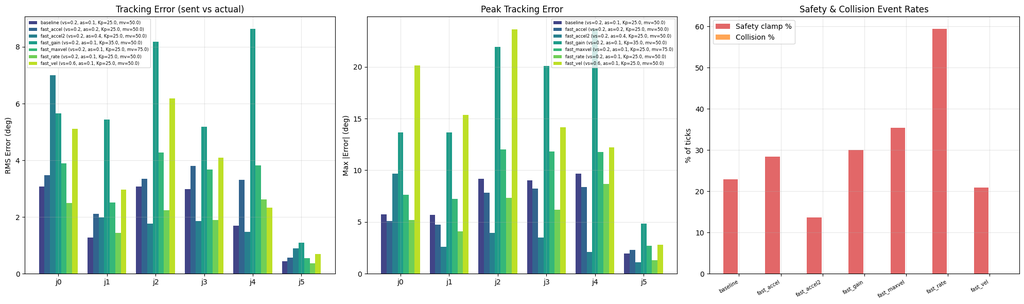

```python
if len(all_runs) < 2:
    print('Need >= 2 runs. Complete your test runs first.')
else:
    # Sort runs by velocity_scale
    sorted_runs = sorted(all_runs, key=lambda r: r['params'].get('velocity_scale', 0))

    fig, axes = plt.subplots(1, 3, figsize=(20, 6))
    labels = [r['display'] for r in sorted_runs]
    x = np.arange(6)
    width = 0.8 / len(sorted_runs)
    colors = plt.cm.viridis(np.linspace(0.2, 0.9, len(sorted_runs)))

    # RMS tracking error
    ax = axes[0]
    for k, run in enumerate(sorted_runs):
        df = run['df_str']
        vals = []
        for i in range(6):
            if f'sent_pos_j{i}' in df.columns and f'actual_j{i}' in df.columns:
                err = np.degrees(df[f'sent_pos_j{i}'] - df[f'actual_j{i}'])
                vals.append(np.sqrt(np.mean(err.values**2)))
            else:
                vals.append(0)
        ax.bar(x + k * width, vals, width, label=labels[k], color=colors[k])
    ax.set_xticks(x + width * (len(sorted_runs) - 1) / 2)
    ax.set_xticklabels([f'j{i}' for i in range(6)])
    ax.set_ylabel('RMS Error (deg)')
    ax.set_title('Tracking Error (sent vs actual)')
    ax.legend(fontsize=6)
    ax.grid(True, alpha=0.3)

    # Max tracking error
    ax = axes[1]
    for k, run in enumerate(sorted_runs):
        df = run['df_str']
        vals = []
        for i in range(6):
            if f'sent_pos_j{i}' in df.columns and f'actual_j{i}' in df.columns:
                err = np.degrees(df[f'sent_pos_j{i}'] - df[f'actual_j{i}'])
                vals.append(np.max(np.abs(err.values)))
            else:
                vals.append(0)
        ax.bar(x + k * width, vals, width, label=labels[k], color=colors[k])
    ax.set_xticks(x + width * (len(sorted_runs) - 1) / 2)
    ax.set_xticklabels([f'j{i}' for i in range(6)])
    ax.set_ylabel('Max |Error| (deg)')
    ax.set_title('Peak Tracking Error')
    ax.legend(fontsize=6)
    ax.grid(True, alpha=0.3)

    # Safety event rate
    ax = axes[2]
    safety_rates = []
    collision_rates = []
    for run in sorted_runs:
        di, ds = run['df_inf'], run['df_str']
        sr = (di['safety_was_constrained'].sum() / len(di) * 100) if 'safety_was_constrained' in di.columns else 0
        cr = (ds['collision_detected'].sum() / len(ds) * 100) if 'collision_detected' in ds.columns else 0
        safety_rates.append(sr)
        collision_rates.append(cr)
    bx = np.arange(len(sorted_runs))
    ax.bar(bx - 0.2, safety_rates, 0.35, label='Safety clamp %', color='tab:red', alpha=0.7)
    ax.bar(bx + 0.2, collision_rates, 0.35, label='Collision %', color='tab:orange', alpha=0.7)
    ax.set_xticks(bx)
    ax.set_xticklabels([r['label'] for r in sorted_runs], rotation=30, ha='right', fontsize=7)
    ax.set_ylabel('% of ticks')
    ax.set_title('Safety & Collision Event Rates')
    ax.legend()
    ax.grid(True, alpha=0.3)

    plt.tight_layout()
    plt.show()
```

## 11. Phase 2: Feedback Parameter Sweep

Compare runs where feedback_gain/feedback_max_vel vary but streamer params are constant. Shows how the feedback controller affects the signal before it reaches the streamer.

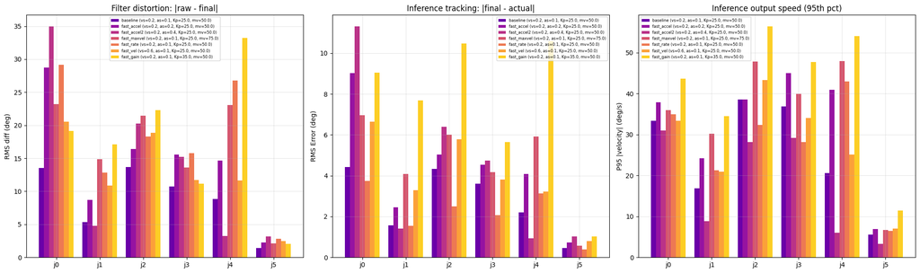

```python
if len(all_runs) < 2:
    print('Need >= 2 runs. Complete your test runs first.')
else:
    # Sort runs by feedback_gain
    sorted_runs = sorted(all_runs, key=lambda r: r['params'].get('feedback_gain', 0))

    fig, axes = plt.subplots(1, 3, figsize=(20, 6))
    labels = [r['display'] for r in sorted_runs]
    x = np.arange(6)
    width = 0.8 / len(sorted_runs)
    colors = plt.cm.plasma(np.linspace(0.2, 0.9, len(sorted_runs)))

    # Inference-side: raw -> final error (how much does the filter change the model output?)
    ax = axes[0]
    for k, run in enumerate(sorted_runs):
        df = run['df_inf']
        vals = []
        for i in range(6):
            if f'raw_j{i}' in df.columns and f'final_j{i}' in df.columns:
                diff = np.degrees(df[f'raw_j{i}'] - df[f'final_j{i}'])
                vals.append(np.sqrt(np.mean(diff.values**2)))
            else:
                vals.append(0)
        ax.bar(x + k * width, vals, width, label=labels[k], color=colors[k])
    ax.set_xticks(x + width * (len(sorted_runs) - 1) / 2)
    ax.set_xticklabels([f'j{i}' for i in range(6)])
    ax.set_ylabel('RMS diff (deg)')
    ax.set_title('Filter distortion: |raw - final|')
    ax.legend(fontsize=6)
    ax.grid(True, alpha=0.3)

    # Inference-side: final -> actual error (tracking quality at inference output)
    ax = axes[1]
    for k, run in enumerate(sorted_runs):
        df = run['df_inf']
        vals = []
        for i in range(6):
            if f'final_j{i}' in df.columns and f'actual_j{i}' in df.columns:
                err = np.degrees(df[f'final_j{i}'] - df[f'actual_j{i}'])
                vals.append(np.sqrt(np.mean(err.values**2)))
            else:
                vals.append(0)
        ax.bar(x + k * width, vals, width, label=labels[k], color=colors[k])
    ax.set_xticks(x + width * (len(sorted_runs) - 1) / 2)
    ax.set_xticklabels([f'j{i}' for i in range(6)])
    ax.set_ylabel('RMS Error (deg)')
    ax.set_title('Inference tracking: |final - actual|')
    ax.legend(fontsize=6)
    ax.grid(True, alpha=0.3)

    # Inference output velocity (how fast are published targets changing?)
    ax = axes[2]
    for k, run in enumerate(sorted_runs):
        df = run['df_inf']
        vals = []
        for i in range(6):
            if f'final_j{i}' in df.columns and len(df) > 1:
                vel = np.gradient(df[f'final_j{i}'].values, df['t'].values)
                vals.append(np.degrees(np.percentile(np.abs(vel), 95)))
            else:
                vals.append(0)
        ax.bar(x + k * width, vals, width, label=labels[k], color=colors[k])
    ax.set_xticks(x + width * (len(sorted_runs) - 1) / 2)
    ax.set_xticklabels([f'j{i}' for i in range(6)])
    ax.set_ylabel('P95 |velocity| (deg/s)')
    ax.set_title('Inference output speed (95th pct)')
    ax.legend(fontsize=6)
    ax.grid(True, alpha=0.3)

    plt.tight_layout()
    plt.show()
```

## 12. Overlay: Velocity Traces Across Runs

Overlay the actual robot velocity (d/dt of actual position) for all runs on the same axes. Directly shows at which settings the robot starts oscillating.

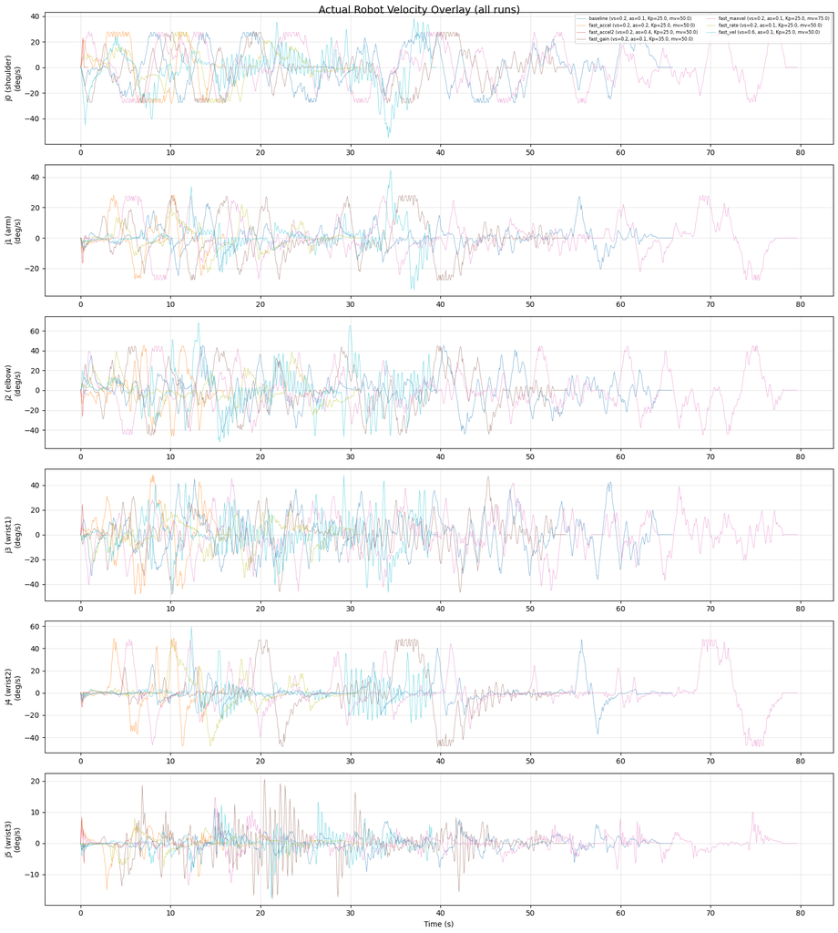

```python
if len(all_runs) < 2:
    print('Need >= 2 runs.')
else:
    fig, axes = plt.subplots(6, 1, figsize=(16, 18), sharex=False)
    colors = plt.cm.tab10(np.linspace(0, 1, min(len(all_runs), 10)))

    for i in range(6):
        ax = axes[i]
        for k, run in enumerate(all_runs):
            df = run['df_str']
            if f'actual_j{i}' in df.columns and len(df) > 1:
                vel = np.gradient(df[f'actual_j{i}'].values, df['t'].values)
                ax.plot(df['t'], np.degrees(vel), linewidth=0.5, alpha=0.7,
                        color=colors[k % len(colors)], label=run['display'])
        ax.set_ylabel(f'{JOINT_NAMES[i]}\n(deg/s)')
        if i == 0:
            ax.legend(loc='upper right', fontsize=6, ncol=2)
        ax.grid(True, alpha=0.3)

    axes[-1].set_xlabel('Time (s)')
    fig.suptitle('Actual Robot Velocity Overlay (all runs)', fontsize=14)
    plt.tight_layout()
    plt.show()
```

## 13. Summary Table

Parameters and key metrics for every run at a glance.

```python
if len(all_runs) >= 1:
    rows = []
    for run in all_runs:
        p = run['params']
        di, ds = run['df_inf'], run['df_str']

        # Compute summary metrics
        rms_errs = []
        for i in range(6):
            if f'sent_pos_j{i}' in ds.columns and f'actual_j{i}' in ds.columns:
                err = np.degrees(ds[f'sent_pos_j{i}'] - ds[f'actual_j{i}'])
                rms_errs.append(np.sqrt(np.mean(err.values**2)))
        mean_rms = np.mean(rms_errs) if rms_errs else 0

        safety_pct = (di['safety_was_constrained'].sum() / len(di) * 100
                      if 'safety_was_constrained' in di.columns else 0)

        rows.append({
            'label': run['label'],
            'vel_scale': p.get('velocity_scale', '?'),
            'accel_scale': p.get('accel_scale', '?'),
            'Kp': p.get('feedback_gain', '?'),
            'max_vel': p.get('feedback_max_vel', '?'),
            'mean_RMS_err_deg': f'{mean_rms:.2f}',
            'safety_clamp_%': f'{safety_pct:.1f}',
            'duration_s': f'{ds["t"].iloc[-1]:.1f}',
            'ticks': len(ds),
        })

    summary = pd.DataFrame(rows)
    print(summary.to_string(index=False))
else:
    print('No runs loaded.')
```

```
      label  vel_scale  accel_scale   Kp  max_vel mean_RMS_err_deg safety_clamp_% duration_s  ticks
   baseline        0.2          0.1 25.0     50.0             2.09           22.9       65.8    987
 fast_accel        0.2          0.2 25.0     50.0             2.77           28.5       16.1    240
fast_accel2        0.2          0.4 25.0     50.0             2.50           13.7        0.8     13
  fast_gain        0.2          0.1 35.0     50.0             5.69           30.0       54.0    808
fast_maxvel        0.2          0.1 25.0     75.0             3.12           35.4       79.7   1193
  fast_rate        0.2          0.1 25.0     50.0             1.84           59.4       31.1    467
   fast_vel        0.6          0.1 25.0     50.0             3.57           21.0       39.5    594
```

## 14. Safety & Collision Events

Timeline of safety clamp events (inference) and collision detections (streamer) for the current run.

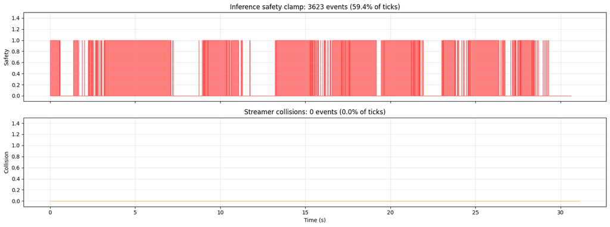

```python
fig, axes = plt.subplots(2, 1, figsize=(16, 6), sharex=True)

ax = axes[0]
if 'safety_was_constrained' in df_inf.columns:
    mask = df_inf['safety_was_constrained'] == 1
    count = mask.sum()
    rate = count / len(df_inf) * 100 if len(df_inf) > 0 else 0
    ax.fill_between(df_inf['t'], 0, df_inf['safety_was_constrained'],
                    alpha=0.5, color='red', step='mid')
    ax.set_title(f'Inference safety clamp: {count} events ({rate:.1f}% of ticks)')
ax.set_ylabel('Safety')
ax.set_ylim(-0.1, 1.5)
ax.grid(True, alpha=0.3)

ax = axes[1]
if 'collision_detected' in df_str.columns:
    mask = df_str['collision_detected'] == 1
    count = mask.sum()
    rate = count / len(df_str) * 100 if len(df_str) > 0 else 0
    ax.fill_between(df_str['t'], 0, df_str['collision_detected'],
                    alpha=0.5, color='orange', step='mid')
    ax.set_title(f'Streamer collisions: {count} events ({rate:.1f}% of ticks)')
ax.set_ylabel('Collision')
ax.set_ylim(-0.1, 1.5)
ax.grid(True, alpha=0.3)
axes[-1].set_xlabel('Time (s)')
plt.tight_layout()
plt.show()
```